# Banknoten

JoKeYa

11/06/2018

## Setup

Als Library wurde ddalpha verwendet. Als Datenset verwenden wir Banknoten.

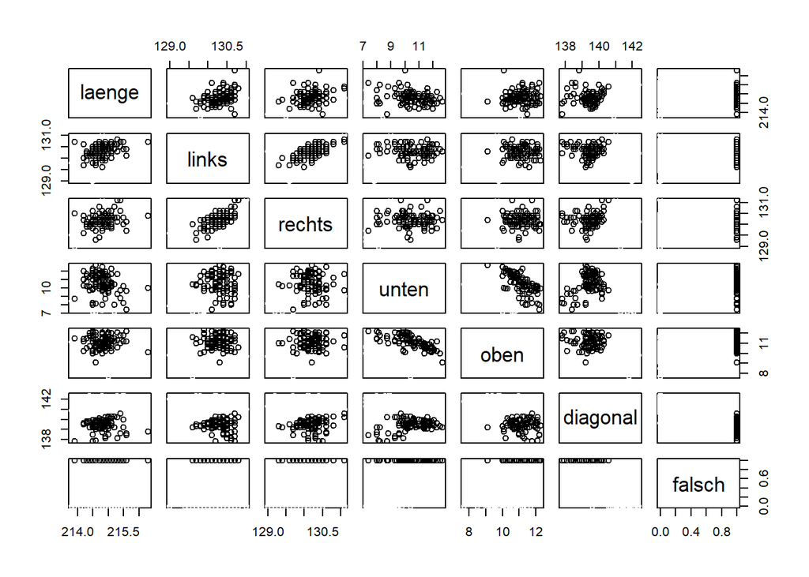

```r
data("banknoten")
plot(banknoten, col = banknoten$falsch)
```

Da die Klassifikation ein Integer ist, kann es wie oben vorkommen, dass der Wert nicht korrekt interpretiert werden kann. Somit muss die Klassifikation zu einem Faktor übersetzt werden.

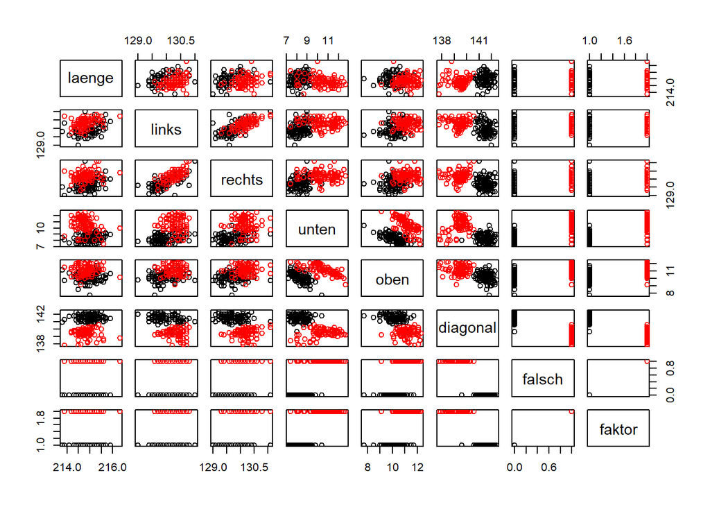

```r
banknoten$faktor <- as.factor(banknoten$falsch)
plot(banknoten, col = banknoten$faktor)
```

Länge: Länge der Banknote

Links: Höhe der Banknote bei der linken Seite

Rechts: Höhe der Banknote bei der rechten Seite

Oben: Distanz zwischen inneren Bereich und oberen Rand

Unten: Distanz zwischen inneren Bereich und unteren Rand

Diagonal: Diagonale Länge der Banknote

## Visualisierung bestehender Daten

```r
head(banknoten)
```

```
##   laenge links rechts unten oben diagonal falsch faktor
## 1  214.8 131.0  131.1   9.0  9.7    141.0      0      0
## 2  214.6 129.7  129.7   8.1  9.5    141.7      0      0
## 3  214.8 129.7  129.7   8.7  9.6    142.2      0      0
## 4  214.8 129.7  129.6   7.5 10.4    142.0      0      0
## 5  215.0 129.6  129.7  10.4  7.7    141.8      0      0
## 6  215.7 130.8  130.5   9.0 10.1    141.4      0      0
```

```r
##Für ROC beibehalten (Ist leider nicht ganz perfekt 1, aber dient zur Anschauung)
beispielRoc <- roc(banknoten$falsch, banknoten$diagonal)

str(banknoten)
```

```
## 'data.frame':    200 obs. of  8 variables:
##  $ laenge  : num  215 215 215 215 215 ...
##  $ links   : num  131 130 130 130 130 ...
##  $ rechts  : num  131 130 130 130 130 ...
##  $ unten   : num  9 8.1 8.7 7.5 10.4 9 7.9 7.2 8.2 9.2 ...
##  $ oben    : num  9.7 9.5 9.6 10.4 7.7 10.1 9.6 10.7 11 10 ...
##  $ diagonal: num  141 142 142 142 142 ...
##  $ falsch  : int  0 0 0 0 0 0 0 0 0 0 ...
##  $ faktor  : Factor w/ 2 levels "0","1": 1 1 1 1 1 1 1 1 1 1 ...
```

```r
colMeans(banknoten[,1:7])
```

```
##   laenge    links   rechts    unten     oben diagonal   falsch
## 214.8960 130.1215 129.9565   9.4175  10.6505 140.4835   0.5000
```

```r
median(banknoten$laenge)
```

```
## [1] 214.9
```

```r
median(banknoten$links)
```

```
## [1] 130.2
```

```r
median(banknoten$rechts)
```

```
## [1] 130
```

```r
median(banknoten$unten)
```

```
## [1] 9.1
```

```r
median(banknoten$oben)
```

```
## [1] 10.6
```

```r
median(banknoten$diagonal)
```

```
## [1] 140.45
```

```r
median(banknoten$falsch)
```

```
## [1] 0.5
```

```r
quantile(banknoten$diagonal, 0.25)
```

```
##   25%
## 139.5
```

Banknoten$falsch wird nicht mehr benötigt und kann die Statistik über den Haufen werfen. Somit wurde es anbei entfernt.

```r
banknoten$falsch = NULL
```

## Definierung der Daten

Bildlich dargestellt wird anbei die Diagonale des Datensets geplottet mit der Unterscheidung von dem Faktor.

Man sieht sehr gut, dass die Daten fast perfekt voneinander getrennt werden können und dementsprechend die Decision Trees ein perfektes Ergebnis eruieren können.

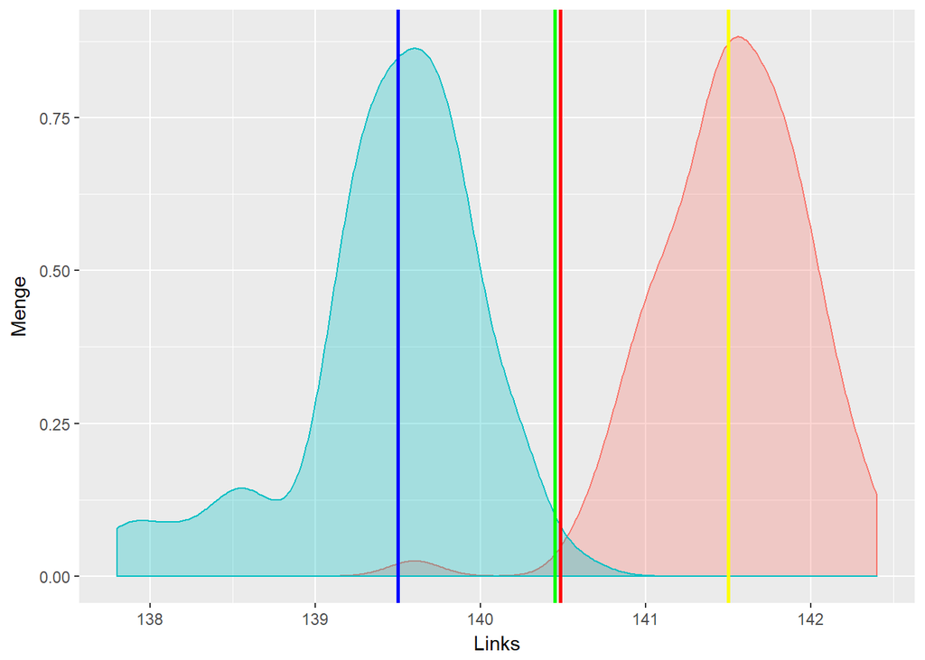

```r
ggplot(banknoten, aes(x=diagonal, colour=faktor, fill=faktor)) +
  geom_density(alpha=.3) +
  geom_vline(aes(xintercept=mean(diagonal,
                 colour=faktor)), color="red", size=1) +
  geom_vline(aes(xintercept=median(diagonal,
                 colour=faktor)), color="green", size=1) +
  geom_vline(aes(xintercept=quantile(diagonal, 0.25),
                 colour=faktor), color="blue", size=1) +
  geom_vline(aes(xintercept=quantile(diagonal, 0.75),
                 colour=faktor), color="yellow", size=1) +
  xlab("Links") +
  ylab("Menge") +
  theme(legend.position="none")
```

Deswegen haben wir uns entschieden die “besten” Datensätze zu entfernen, damit wir überhaupt Fehlerquellen erhalten.

### Wichtigkeit der Variablen (MeanDecreaseGini)

```r
control <- trainControl(method = "repeatedcv", number = 10, repeats = 3)
banknoten.rf <- randomForest(faktor ~ ., data = banknoten, ntree=1000, keep.forest=FALSE, importance=TRUE)

varImp(banknoten.rf)
```

```
##                  0         1
## laenge    2.404629  2.404629
## links     6.322283  6.322283
## rechts    6.494813  6.494813
## unten    28.359884 28.359884
## oben     17.163501 17.163501
## diagonal 49.214002 49.214002
```

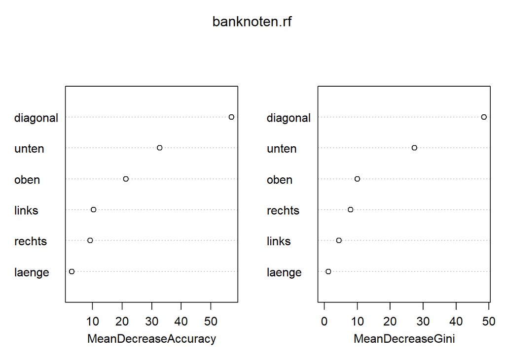

```r
varImpPlot(banknoten.rf)
```

Da diagonal, Unten, Rechts und Oben die wichtigsten 4 Datensätze sind, werden sie entfernt.

Jetzt ist es nicht mehr so eindeutig, bzw. sind die wahren von den falschen Werten weniger gut zu unterscheiden.

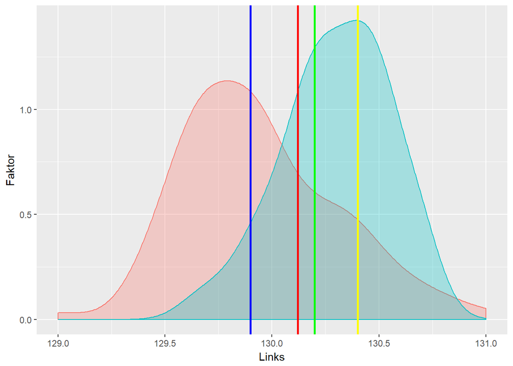

```r
banknoten$diagonal = NULL
banknoten$unten = NULL
banknoten$rechts = NULL
banknoten$oben = NULL

ggplot(banknoten, aes(x=links, colour=faktor, fill=faktor)) +
  geom_density(alpha=.3) +
  geom_vline(aes(xintercept=mean(links,
                 colour=faktor)), color="red", size=1) +
  geom_vline(aes(xintercept=median(links,
                 colour=faktor)), color="green", size=1) +
  geom_vline(aes(xintercept=quantile(links, 0.25),
                 colour=faktor), color="blue", size=1) +
  geom_vline(aes(xintercept=quantile(links, 0.75),
                 colour=faktor), color="yellow", size=1) +
  xlab("Links") +
  ylab("Faktor") +
  theme(legend.position="none")
```

## Erstellung des Training- und Testsets

Die zwei Spalten sind nun dmentsprechend mehr Wert als vorhin.

```r
set.seed(13)
trainIndex <- createDataPartition(banknoten$faktor, p = .6,
                                  list = FALSE, times = 1)

trainSet <- banknoten[trainIndex, ]
testSet <- banknoten[-trainIndex,]

model <- randomForest(formula = faktor ~ ., data = banknoten)

testSet$prediction <- predict(model, testSet[,1:3])

importance(model)
```

```
##        MeanDecreaseGini
## laenge         25.39407
## links          44.81845
```

### Confusion matrix

Die Konfusions-Matrix stellt, wie bekannt, die True Positives, False Positives, True Negatives und False Negatives.

#### Specifity

True Negatives durch alle wahren Negativen, die vorhanden sind

#### Sensitivity

True Positives durch alle wahren Positiven, die vorhanden sind

```r
confusionMatrix(testSet$prediction, testSet$faktor)
```

```
## Confusion Matrix and Statistics
##
##           Reference
## Prediction  0  1
##          0 38  4
##          1  2 36
##
##                Accuracy : 0.925
##                  95% CI : (0.8439, 0.972)
##     No Information Rate : 0.5
##     P-Value [Acc > NIR] : 2.698e-16
##
##                   Kappa : 0.85
##  Mcnemar's Test P-Value : 0.6831
##
##             Sensitivity : 0.9500
##             Specificity : 0.9000
##          Pos Pred Value : 0.9048
##          Neg Pred Value : 0.9474
##              Prevalence : 0.5000
##          Detection Rate : 0.4750
##    Detection Prevalence : 0.5250
##       Balanced Accuracy : 0.9250
##
##        'Positive' Class : 0
##
```

### ROC Curve

(Die blaue Linie ist leider nicht perfekt auf 1, jedoch dient sie gut zur Veranschauung, was optimal wäre.)

Eine ROC Curve stellt für EINE dieser Werte seine entsprechende Kurve dar, wie gut diese klassifiziert werden kann.

Wie oben zu sehen ist, wird entsprechend der Importance-Tabelle grafisch ersichtlich, dass “Links” bessere Werte liefern kann, denn die AUC (Area Under the Curve) is grösser, bzw. werden weniger werte falsch eingestuft. Wenn die ROC näher an der blauen Ideallinie ist, desto besser konnte es von den Desicion Trees korrekt identifiziert werden.

Dementsprechend ist beim oberen der beiden ROC die Fehlerrate höher, da weniger genau geschätzt werden kann, bzw. weniger Werte korrekt eingeschätzt werden können

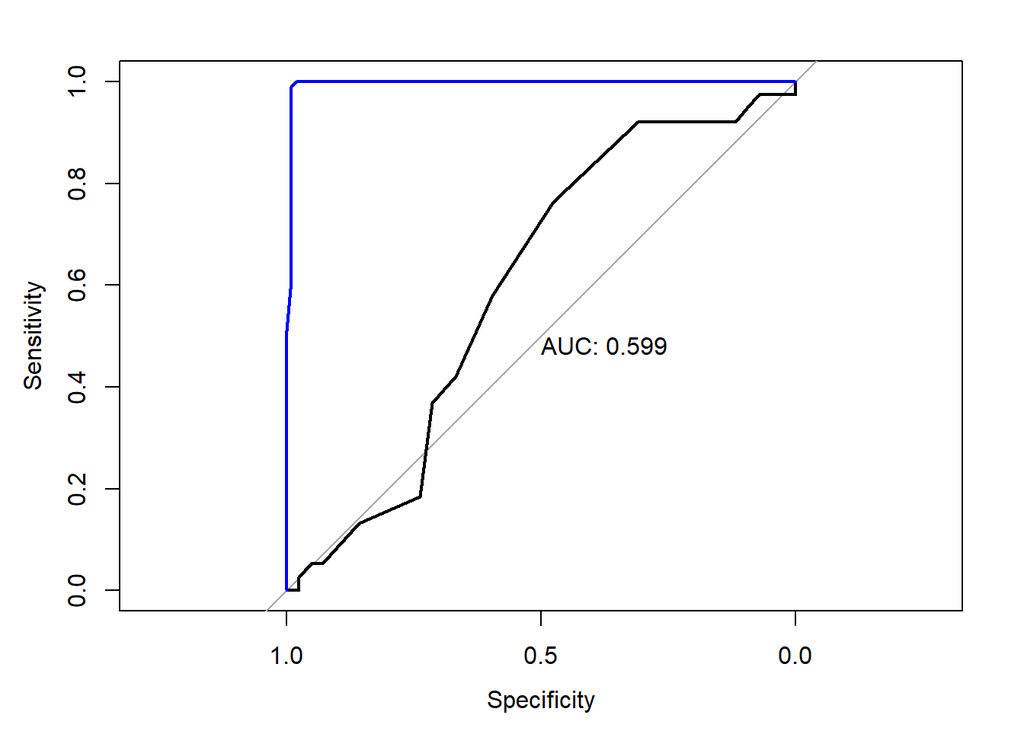

```r
plot(roc(testSet$prediction, testSet$laenge), print.auc=TRUE)
lines(beispielRoc, col="blue")
```

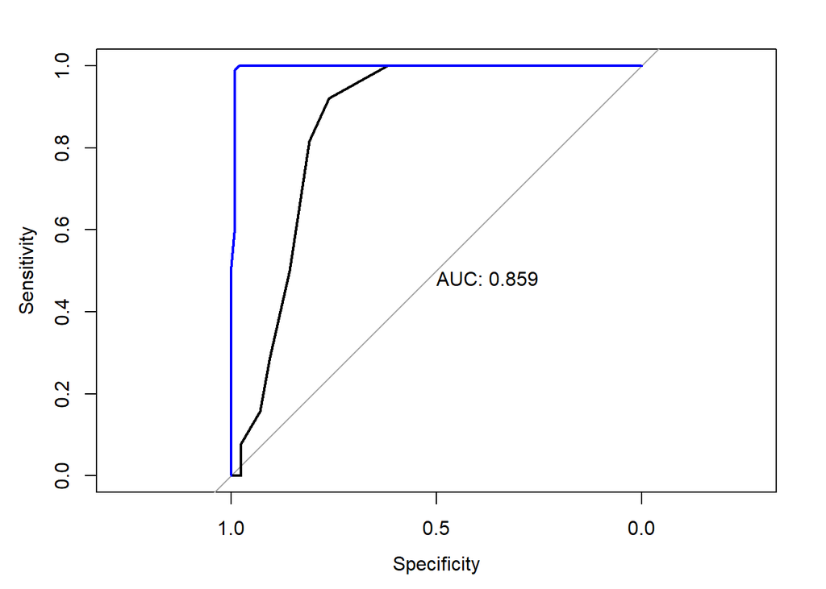

```r
plot(roc(testSet$prediction, testSet$links), print.auc=TRUE)
lines(beispielRoc, col="blue")
```

## Out-of-Bag Error

Zu Beginn teilt man das Dataset in Trainings-Daten und Test-Daten auf. Mit den Trainings-Daten wird der Algorithmus trainiert. Wird nun der trainierte Algorithmus auf die Test-Daten angewendet, so erhalten wir eine mögliche Fehlerrate bei der Kategorisierung. Diese Fehlerrate nennt man Out-of-Bag Error, und ist eine Schätzung wie genau der Algorithmus ist.